# Project 2: Data Mining, Classification, Prediction

SDS322E

# Mining, Classification, Prediction

## Alex Kim UTEid: ak37642

### Introduction

I decided to go with data I found online from the list (https://vincentarelbundock.github.io/Rdatasets/datasets.html) provided on the project instructions. I decided to go for data that still went along with traffic fatalities, but I wanted to see other potential factors that were different from the health data I found in project part 1. With this, I wanted to explore the relationship between traffic fatalities and the various aspects of drunking driving for states within the United States from 1987 to 1988. As I’ve mentioned, I’m really big on looking at the news, so I wanted to continue to observe the possible associations of traffic fatality rates with the variables in this dataset even further. There are many different factors that tie into traffic fatalities, but it’s interesting to see whether there are possible associations with things like unemployment rate, the tax on beers, policies of the state and more.

Some of the variables in my dataset include the traffic fatality rate, year, state ID code, tax on cases of beer, whether there is a mandatory jail sentence, whether there is a mandatory community service, average miles per driver, the unemployment rate, and per capita personal income. I decided to change my binary variables to be a logical type so that it would be easier later on (TRUE/FALSE) instead of yes or no. There are 96 observations in total. Out of the 96 observations, 28 were found to include mandatory jail sentence while 68 do not include mandatory jail sentence. Furthermore out of the 96 observations, 20 require mandatory community serivce, while 76 do not.

```r
library(tidyverse)
# read your datasets in here, e.g., with read_csv()
library(readr)
fatality <- read_csv("~/project2/Fatality 1.csv")

# Renaming the columns
fatality <- fatality %>% rename(FatalityRate = mrall, BeerTax = beertax,
    Jail = jaild, CommunityServ = comserd, MilesAvg = vmiles,
    Unemployment = unrate, PersonalIncome = perinc)
fatality <- fatality %>% mutate(Jail = ifelse(Jail == "yes",
    "TRUE", "FALSE"))
fatality <- fatality %>% mutate(CommunityServ = ifelse(CommunityServ ==
    "yes", "TRUE", "FALSE"))
fatality %>% filter(Jail == "TRUE")
```

```
## # A tibble: 28 x 10
##       X1 state  year FatalityRate BeerTax Jail  CommunityServ MilesAvg
##    <dbl> <dbl> <dbl>        <dbl>   <dbl> <chr> <chr>            <dbl>
##  1     3     4  1987         2.77   0.360 TRUE  TRUE              9.37
##  2     4     4  1988         2.71   0.346 TRUE  TRUE              9.82
##  3    11     9  1987         1.40   0.226 TRUE  TRUE              8.34
##  4    12     9  1988         1.50   0.217 TRUE  TRUE              8.06
##  5    27    20  1987         1.98   0.406 TRUE  TRUE              8.30
##  6    28    20  1988         1.94   0.390 TRUE  TRUE              8.48
##  7    31    22  1987         1.85   0.726 TRUE  TRUE              6.86
##  8    32    22  1988         2.10   0.699 TRUE  TRUE              7.87
##  9    33    23  1987         1.95   0.788 TRUE  FALSE             9.07
## 10    34    23  1988         2.12   0.758 TRUE  FALSE             9.46
## # … with 18 more rows, and 2 more variables: Unemployment <dbl>,
## #   PersonalIncome <dbl>
```

```r
fatality %>% filter(CommunityServ == "TRUE")
```

```
## # A tibble: 20 x 10
##       X1 state  year FatalityRate BeerTax Jail  CommunityServ MilesAvg
##    <dbl> <dbl> <dbl>        <dbl>   <dbl> <chr> <chr>            <dbl>
##  1     3     4  1987         2.77   0.360 TRUE  TRUE              9.37
##  2     4     4  1988         2.71   0.346 TRUE  TRUE              9.82
##  3     9     8  1987         1.79   0.180 FALSE TRUE              8.18
##  4    10     8  1988         1.51   0.173 FALSE TRUE              8.38
##  5    11     9  1987         1.40   0.226 TRUE  TRUE              8.34
##  6    12     9  1988         1.50   0.217 TRUE  TRUE              8.06
##  7    15    12  1987         2.36   1.08  FALSE TRUE              7.79
##  8    16    12  1988         2.50   1.04  FALSE TRUE              8.54
##  9    27    20  1987         1.98   0.406 TRUE  TRUE              8.30
## 10    28    20  1988         1.94   0.390 TRUE  TRUE              8.48
## 11    31    22  1987         1.85   0.726 TRUE  TRUE              6.86
## 12    32    22  1988         2.10   0.699 TRUE  TRUE              7.87
## 13    51    32  1987         2.60   0.203 TRUE  TRUE              8.34
## 14    52    32  1988         2.71   0.195 TRUE  TRUE              8.53
## 15    69    41  1987         2.28   0.189 TRUE  TRUE              8.57
## 16    70    41  1988         2.45   0.182 TRUE  TRUE              9.11
## 17    75    45  1987         3.17   1.73  TRUE  TRUE              8.82
## 18    76    45  1988         2.98   1.66  TRUE  TRUE              9.15
## 19    83    49  1987         1.76   0.798 TRUE  TRUE              7.55
## 20    84    49  1988         1.76   0.768 TRUE  TRUE              7.85
## # … with 2 more variables: Unemployment <dbl>, PersonalIncome <dbl>
```

### Cluster Analysis

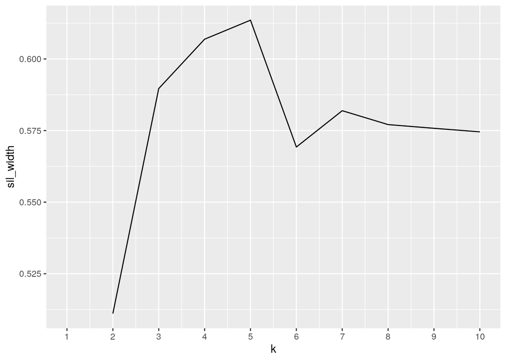

```r
library(cluster)
# clustering code here
fatality_dat <- fatality %>% select(FatalityRate, BeerTax, MilesAvg,
    Unemployment, PersonalIncome)

sil_width <- vector()
for (i in 2:10) {
    pam_fit <- pam(fatality_dat, k = i)
    sil_width[i] <- pam_fit$silinfo$avg.width
}
ggplot() + geom_line(aes(x = 1:10, y = sil_width)) + scale_x_continuous(name = "k",
    breaks = 1:10)
```

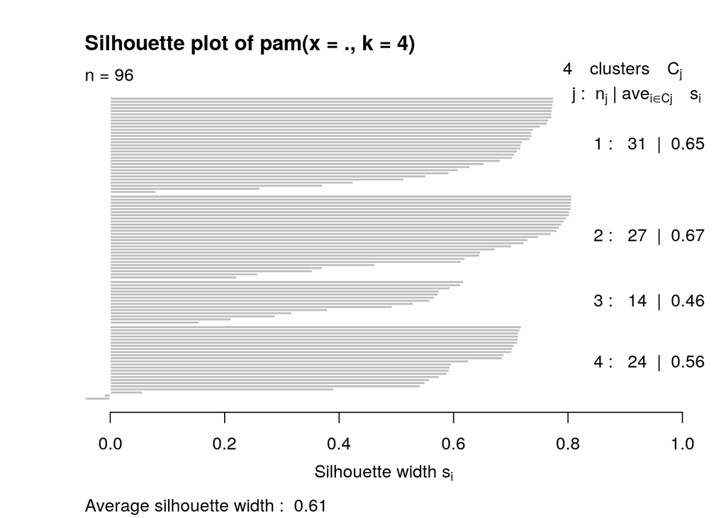

```r
fatality_pam <- fatality_dat %>% pam(k = 4)
plot(fatality_pam, which = 2)
```

```r
fatality %>% slice(fatality_pam$id.med)
```

```
## # A tibble: 4 x 10
##      X1 state  year FatalityRate BeerTax Jail  CommunityServ MilesAvg
##   <dbl> <dbl> <dbl>        <dbl>   <dbl> <chr> <chr>            <dbl>
## 1    75    45  1987         3.17   1.73  TRUE  TRUE              8.82
## 2    17    13  1987         2.57   2.28  FALSE FALSE             9.69
## 3    36    24  1988         1.69   0.194 FALSE FALSE             8.11
## 4    41    27  1987         1.25   0.316 FALSE FALSE             8.28
## # … with 2 more variables: Unemployment <dbl>, PersonalIncome <dbl>
```

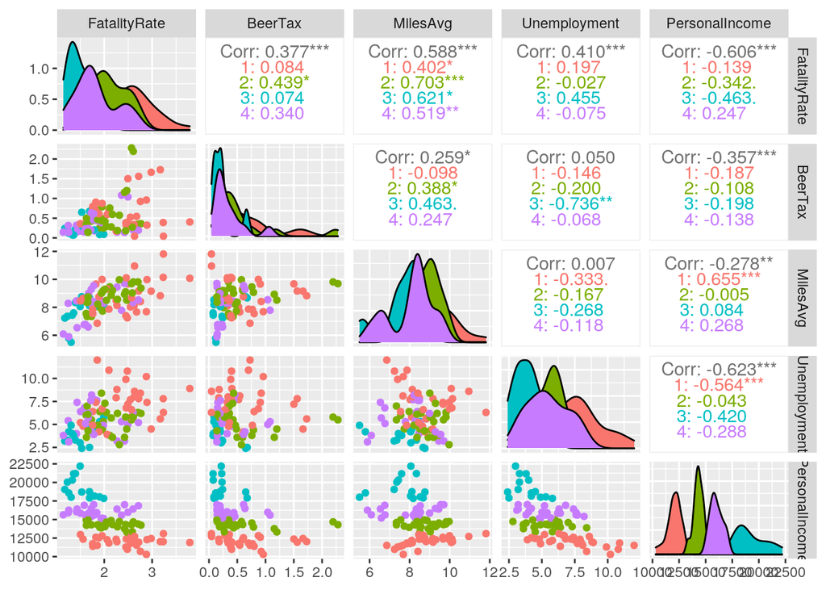

```r
# Pairiwse combinations of the variables
library(GGally)
fatality_cluster <- fatality_dat %>% mutate(cluster = as.factor(fatality_pam$clustering))
ggpairs(fatality_cluster, columns = 1:5, aes(color = cluster))
```

### Dimensionality Reduction with PCA

```r
# PCA code here
fatality_sel <- fatality %>% select(c(4, 5, 8, 9, 10))
pca_fatality <- princomp(fatality_sel, cor = TRUE)
summary(pca_fatality)
```

```
## Importance of components:
##                           Comp.1    Comp.2    Comp.3     Comp.4     Comp.5
## Standard deviation     1.5819965 1.0759027 0.8834991 0.53935728 0.51792235
## Proportion of Variance 0.5005426 0.2315133 0.1561141 0.05818125 0.05364871
## Cumulative Proportion  0.5005426 0.7320559 0.8881700 0.94635129 1.00000000
```

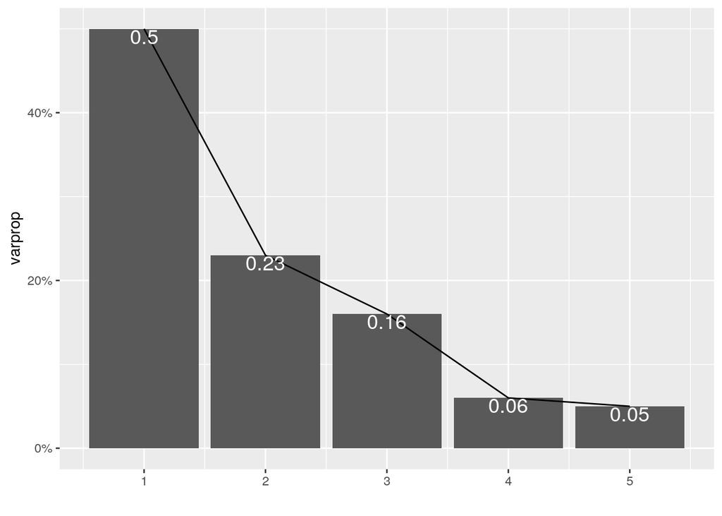

```r
eigval_pca <- pca_fatality$sdev^2
varprop = round(eigval_pca/sum(eigval_pca), 2)
ggplot() + geom_bar(aes(y = varprop, x = 1:5), stat = "identity") +
    xlab("") + geom_path(aes(y = varprop, x = 1:5)) + geom_text(aes(x = 1:5,
    y = varprop, label = round(varprop, 2)), vjust = 1, col = "white",
    size = 5) + scale_y_continuous(breaks = seq(0, 0.6, 0.2),
    labels = scales::percent) + scale_x_continuous(breaks = 1:10)
```

```r
round(cumsum(eigval_pca)/sum(eigval_pca), 3)
```

```
## Comp.1 Comp.2 Comp.3 Comp.4 Comp.5
##  0.501  0.732  0.888  0.946  1.000
```

```r
summary(pca_fatality, loadings = T)
```

```
## Importance of components:
##                           Comp.1    Comp.2    Comp.3     Comp.4     Comp.5
## Standard deviation     1.5819965 1.0759027 0.8834991 0.53935728 0.51792235
## Proportion of Variance 0.5005426 0.2315133 0.1561141 0.05818125 0.05364871
## Cumulative Proportion  0.5005426 0.7320559 0.8881700 0.94635129 1.00000000
##
## Loadings:
##                Comp.1 Comp.2 Comp.3 Comp.4 Comp.5
## FatalityRate    0.554  0.132  0.222  0.495  0.617
## BeerTax         0.343  0.371 -0.821  0.154 -0.216
## MilesAvg        0.376  0.563  0.510 -0.176 -0.501
## Unemployment    0.386 -0.666         0.365 -0.520
## PersonalIncome -0.534  0.291  0.109  0.753 -0.227
```

```r
pca_fatality$scores %>% cor %>% round(5)
```

```
##        Comp.1 Comp.2 Comp.3 Comp.4 Comp.5
## Comp.1      1      0      0      0      0
## Comp.2      0      1      0      0      0
## Comp.3      0      0      1      0      0
## Comp.4      0      0      0      1      0
## Comp.5      0      0      0      0      1
```

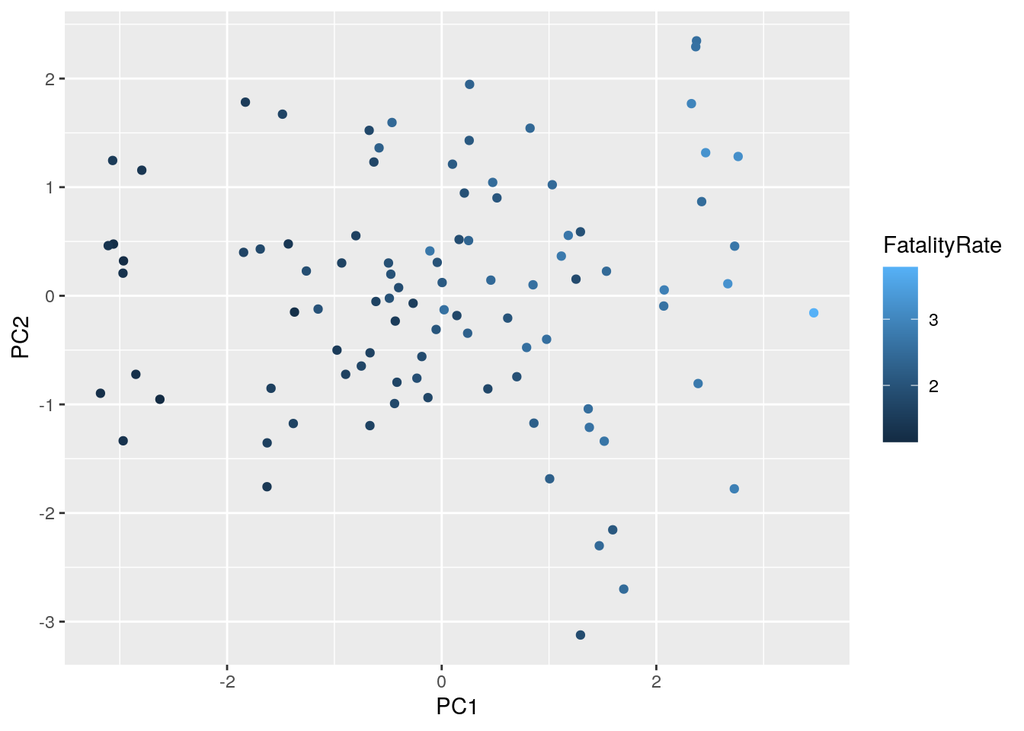

```r
# Plotting PC scores with respect to the first 2 PCs colored
# by the Fatality Rate variable
fatality %>% as.data.frame %>% mutate(PC1 = pca_fatality$scores[,
    1], PC2 = pca_fatality$scores[, 2]) %>% ggplot(aes(PC1, PC2,
    color = FatalityRate)) + geom_point()
```

The first 3 PCs explain 89% of the total variance. This was seen through the plot in which we were able to see that the first three PCs exceeded 85% of the total variance with the PCs explaining around 89% of the variance. The loadings for PC1 generally seem to mean that a higher score will score higher for all the other factors (fatality rate, beer tax, average miles driven, and unemployment (excluding personal income because it loads negatively)). A lower score on PC1 would mean lower scores for all the other factors (excluding personal income because it loads negatively). Higher scores on PC2 would mean higher scores on Fatality rate, Beer tax, average miles per driver, and personal income, but a worse score for unemployment rate. Conversely, a lower score in PC2 would mean lower scores on Fatality rate, Beer tax, average miles per driver, and personal income, but a higher score for unemployment rate. Lastly, higher scores on PC3 mean a higher score for fatality rate, average miles per driver, and personal income, but a lower value for beer tax. On the other hand, a lower score for PC3 would mean a lower score for fatality rate, average miles per driver, and personal income, but a higher value for beer tax.

### Linear Classifier

```r
# linear classifier code here
fatality_logisticfit <- glm(Jail == "TRUE" ~ FatalityRate + BeerTax +
    MilesAvg + Unemployment + PersonalIncome, data = fatality,
    family = "binomial")
fatalityprob_reg <- predict(fatality_logisticfit, type = "response")
class_diag(fatalityprob_reg, truth = fatality$Jail, positive = "TRUE")
```

```
##            acc   sens   spec    ppv     f1     ba    auc
## Metrics 0.7396 0.1786 0.9706 0.7143 0.2857 0.5746 0.7227
```

```r
# Confusion Matrix
table(truth = fatality$Jail == "TRUE", prediction = fatalityprob_reg >
    0.5) %>% addmargins()
```

```
##        prediction
## truth   FALSE TRUE Sum
##   FALSE    66    2  68
##   TRUE     23    5  28
##   Sum      89    7  96
```

```r
TNR = 66/68
TNR
```

```
## [1] 0.9705882
```

```r
TPR = 5/28
TPR
```

```
## [1] 0.1785714
```

```r
FNR = 1 - TPR
FNR
```

```
## [1] 0.8214286
```

```r
FPR = 1 - TNR
FPR
```

```
## [1] 0.02941176
```

This logistic regression predicted the binary variable of Jail to the rest of the numeric variables in the dataset. Per the model, the AUC value was 0.7227. With an AUC value falling in the range of 0.7 and 0.8, this AUC is considered to be fair. Not too great but not too bad.

For the linear classification, I generated a confusion matrix. The proportion of actual negatives correctly classified was 0.9706, which is also considered to be the true negative rate (TNR) or the specificity. Next, the proportion of actual positives being correctly classified 0.17857. This is called the true positive rate (TPR) or the sensitivity. The proportion of those that were true were classified as false, which in this case was 0.82143. This is called the false negative rate, or FNR. The proportion of those that were false were classified as true is called the false positive rate. In this case, that was 0.02941.

```r
# cross-validation of linear classifier here
set.seed(350)
k = 10

data <- sample_frac(fatality)
folds <- rep(1:k, length.out = nrow(data))

diags <- NULL

i = 1
for (i in 1:k) {
    train <- data[folds != i, ]
    test <- data[folds == i, ]
    truth <- test$Jail

    fit <- glm(Jail == "TRUE" ~ FatalityRate + BeerTax + MilesAvg +
        Unemployment + PersonalIncome, data = train, family = "binomial")
    probs <- predict(fit, newdata = test, type = "response")
    diags <- rbind(diags, class_diag(probs, truth, positive = "TRUE"))
}

summarize_all(diags, mean)
```

```
##       acc  sens   spec ppv  f1      ba     auc
## 1 0.69779 0.125 0.9375 NaN NaN 0.53125 0.56785
```

After performing a k-fold cross validation with this model, the auc came out to 0.56785. This would be an indication that overfitting could be occurring. Before performing a k-fold cross validation, the model gave us an AUC of 0.7227. Now after the 10-fold cross validation, the AUC decreased to 0.56785. Since the AUC value falls within the range of 0.5-0.6, it seems to be performing “badly”! Overall, there seems to be signs of overfitting with this model.

### Non-Parametric Classifier

```r
library(caret)
# non-parametric classifier code here
knn_fit <- knn3(Jail == "TRUE" ~ FatalityRate + BeerTax + MilesAvg +
    Unemployment + PersonalIncome, data = fatality)
prob_knn <- predict(knn_fit, newdata = fatality)
class_diag(prob_knn[, 2], truth = fatality$Jail, positive = "TRUE")
```

```
##            acc   sens   spec    ppv     f1     ba    auc
## Metrics 0.7188 0.2143 0.9265 0.5455 0.3077 0.5704 0.7442
```

```r
# Confusion Matrix
table(truth = fatality$Jail == "TRUE", prediction = prob_knn[,
    2] > 0.5) %>% addmargins()
```

```
##        prediction
## truth   FALSE TRUE Sum
##   FALSE    63    5  68
##   TRUE     22    6  28
##   Sum      85   11  96
```

```r
TNR = 63/68
TNR
```

```
## [1] 0.9264706
```

```r
TPR = 6/28
TPR
```

```
## [1] 0.2142857
```

```r
FNR = 1 - TPR
FNR
```

```
## [1] 0.7857143
```

```r
FPR = 1 - TNR
FPR
```

```
## [1] 0.07352941
```

Following what we did in the previous steps, this time we used k-nearest-neighbors to our binary variable of jail to our numeric variables. Per the model, the AUC value was 0.7442. With an AUC value falling in the range of 0.7-0.8, this AUC is considered to be fair. Again, it’s not too bad, but it’s also not too great.

For the non-parametric classification, I generated a confusion matrix. The proportion of actual negatives correctly classified was 0.9265, which is also considered to be the true negative rate (TNR) or the specificity. Next, the proportion of actual positives being correctly classified 0.2142857. This is called hte true positive rate (TPR) or the sensitivity. The proportion of those that were true were classified as false, which in this case was 0.7857143. This is called the false negative rate, or FNR. The proportion of those that were false were classified as true is called the false positive rate. In this case, that was 0.07353.

```r
# cross-validation of np classifier here
set.seed(350)
k = 10

data <- sample_frac(fatality)
folds <- rep(1:k, length.out = nrow(data))

diags <- NULL

i = 1
for (i in 1:k) {
    train <- data[folds != i, ]
    test <- data[folds == i, ]
    truth <- test$Jail

    fit <- knn3(Jail ~ FatalityRate + BeerTax + MilesAvg + Unemployment +
        PersonalIncome, data = train)

    probs <- predict(fit, newdata = test)[, 2]
    diags <- rbind(diags, class_diag(probs, truth, positive = "TRUE"))
}
summarize_all(diags, mean)
```

```
##       acc    sens    spec ppv  f1      ba     auc
## 1 0.67668 0.14166 0.88531 NaN NaN 0.51349 0.52982
```

After performing a k-fold cross validation with this model, the AUC came out to 0.52982. This would be an indication that overfitting could be occurring because our AUC value decrease with the model predicting new observations per CV AUC. Before performing a k-fold cross validation, the model gave us an AUC of 0.7442. Now after the k-fold cross validation, the AUC decreased to 0.52982. Since the AUC value falls within the range of 0.5-0.6, it seems to be performing “badly”! Overall, there seems to be signs of overfitting with this model. When comparing our nonparametric model with the linear model (0.56785) in their cross-validation performance, the nonparametric (0.52982) one seems to be performing slightly worse. However, they are both performing “badly”.

### Regression/Numeric Prediction

```r
# regression model code here
fit_reg <- lm(FatalityRate ~ ., data = fatality)
yhat_reg <- predict(fit_reg)
mean((fatality$FatalityRate - yhat_reg)^2)
```

```
## [1] 0.1054362
```

```r
# cross-validation of regression model here
set.seed(1250)
k = 5

data <- fatality[sample(nrow(fatality)), ]
folds <- cut(seq(1:nrow(fatality)), breaks = k, labels = F)
diags <- NULL
for (i in 1:k) {
    train <- data[folds != i, ]
    test <- data[folds == i, ]
    fit <- lm(FatalityRate ~ ., data = train)
    yhat <- predict(fit, newdata = test)
    diags <- mean((test$FatalityRate - yhat)^2)
}
mean(diags)
```

```
## [1] 0.121028
```

After fitting a linear regression model to the dataset predicting the fatality rate to all other variables, the MSE turned out to be 0.10544. MSE is a measure of prediction error; therefore, we’d want to see a smaller number. I performed k-fold CV on this model and found a MSE value of 0.12103. Since this MSE is a bit higher in CV, this could mean that some overfitting is occurring.

### Python

```r
library(reticulate)
use_python("/usr/bin/python3")
```

```python
# python code here
fatalitypyt = r.fatality
fatalitypyt.head()
```

```
##     X1  state    year  ...  MilesAvg  Unemployment PersonalIncome
## 0  1.0    1.0  1987.0  ...  9.166302           7.8   11944.000000
## 1  2.0    1.0  1988.0  ...  9.674323           7.2   12368.624023
## 2  3.0    4.0  1987.0  ...  9.370654           6.2   14241.000000
## 3  4.0    4.0  1988.0  ...  9.815721           6.3   14408.084961
## 4  5.0    5.0  1987.0  ...  7.665831           8.1   11537.000000
##
## [5 rows x 10 columns]
```

```python
type(fatalitypyt)
```

```
## <class 'pandas.core.frame.DataFrame'>
```

```python
fatalitypyt["MilesAvg"].mean()
```

```
## 8.453054011027016
```

```python
fatalitypyt["MilesAvg"].head()
```

```
## 0    9.166302
## 1    9.674323
## 2    9.370654
## 3    9.815721
## 4    7.665831
## Name: MilesAvg, dtype: float64
```

```python
fatalitypyt["Unemployment"].std()
```

```
## 1.9893066488922986
```

```r
head(py$fatalitypyt)
```

```
##   X1 state year FatalityRate   BeerTax  Jail CommunityServ MilesAvg
## 1  1     1 1987      2.71859 1.5599999 FALSE         FALSE 9.166302
## 2  2     1 1988      2.49391 1.5014436 FALSE         FALSE 9.674323
## 3  3     4 1987      2.76728 0.3600000  TRUE          TRUE 9.370654
## 4  4     4 1988      2.70565 0.3464870  TRUE          TRUE 9.815721
## 5  5     5 1987      2.67588 0.5450000 FALSE         FALSE 7.665831
## 6  6     5 1988      2.54697 0.5245429 FALSE         FALSE 8.024625
##   Unemployment PersonalIncome
## 1          7.8       11944.00
## 2          7.2       12368.62
## 3          6.2       14241.00
## 4          6.3       14408.08
## 5          8.1       11537.00
## 6          7.7       11760.35
```

```r
head(py$fatalitypyt["MilesAvg"])
```

```
##   MilesAvg
## 1 9.166302
## 2 9.674323
## 3 9.370654
## 4 9.815721
## 5 7.665831
## 6 8.024625
```

Being able to switch between R and python is intersting because python code chunks will be able to talk to R code chunks. In the last step, I showed that I knew how to also incorporate my python dataset to R using py$fatalitypyt. This showed that I was also able to communicate from python to R.

### Concluding Remarks

I wanted to still go towards traffic laws and fatalities, but it was really interesting to investigate this new dataset even further. I feel like this project really tested all of the things we learned this second half of the semester. It was definitely pretty challenging to try to figure out where I went wrong sometimes with my code; however, I really enjoyed it! I feel like I really got a lot out of this class and it was very rewarding.